# paper1

Kianté Fernandez

10/13/2020

#Paper 1

## Participants

A total of 616 participants were recruited from Amazon Mechanical Turk (MTurk). MTurk allows researchers to collect high-quality data rapidly among demographically diverse individuals . Prior work has shown that MTurk can be reliably used to make inferences about a number of broader populations of interest . The participants were required to be located within the United States, over the age of 18, fluent in English. While limitations apply the MTurk studies (see Limitations in the Discussion), studies have shown that the quality of MTurk responses can improve with researcher constraints . In the current study, we required that participants had previously completed at least 100 tasks and maintained at least a 95% approval rating on MTurk. We additionally applied exclusions to further ensure that we analyzed high-quality behavioral data (see Exclusions). Our final sample was 392participants.The total sample consisted of 162 females, $M_{age}$ = 36.2 years of age ($SD_{age}$ = 10.83), with 108 high school, 224 undergraduate, and 59 postgraduate, and identified as White/Caucasian (*n* = 269), Asian (*n* = 41), Hispanic/Latino (*n* = 22), Black/African American (*n* = 39), Pacific Islander (*n* = 1) other/multiple (*n* = 11), or did not disclose their ethnicity (*n* = 2). The included subjects completed the task in an average of $M_{task}$ = 7.72 minutes ($SD_{task}$ = 9.84) and the survey in an average of $M_{survey}$ = 19.51 minutes ($SD_{survey}$ = 13.41).

## Exlclusion Criteria

In line with recommendations for studies conducted using Amazons Mechanical Turk (AMT) service, careful instructions and exclusion criteria were applied to further ensure data quality . Using a multi-method approach to detect careless/invalid responses in online samples, several data exclusion criteria were applied . A total of 224 participants were excluded. Participants single trials were excluded if response times were either 250 milli-seconds or above 90 seconds. Given that participants had ample time to respond to each question (up to as long until they made a decision), we reasoned that these participants were not devoting sufficient attention to the task. Additionally, having considered trial wise exclusions, participants were also excluded for failure to complete at least 40 trials in the specified range. Finally, participants were excluded for failure of passing four attention check items and a total survey completion time below five minutes. Because our survey battery involved 11 different assessments, we reasoned that a total completion time below five minutes reflected a careless responder. Our overall exclusion rate of 36.4% is well in line with research findings studying quality control measures on MTurk .

*Data analytic exclusions* We decided in advance chose to exclude the 5% of participants with the poorest model fit based on Nagelkerke’s $R^2$ (see also , with the objective of removing participants who responded most randomly and inconsistently. Lastly, participants were excluded for selecting a “yes” or “no” response at least 90% of the total number of trials. These patterns of stereotyped responses preclude the ability to estimate reliable coefficients in our statistical models. Furthermore, they could result from individuals who are not responding to the information presented on screen during the task. None of the analyses reported yields qualitatively different results if all participants’ data are retained.

```
## [1] "Three Hundred and Ninety Two participants (Mean age = 36.2, SD = 10.8, range: [18, 86]; 41.3% females; Education: less than high school, 0.26%; HighSchool, 27.55%; Undergraduate, 57.14%; Postgraduate, 15.05%)"
```

| **Characteristic** | **N** | **less than high school**, N = 1<sup>1</sup> | **HighSchool**, N = 108<sup>1</sup> | **Undergraduate**, N = 222<sup>1</sup> | **Postgraduate**, N = 59<sup>1</sup> |
| --- | --- | --- | --- | --- | --- |
| sex | 390 |  |  |  |  |
| Male |  | 1 (100%) | 59 (55%) | 130 (59%) | 36 (61%) |
| Female |  | 0 (0%) | 49 (45%) | 90 (41%) | 22 (37%) |
| Other |  | 0 (0%) | 0 (0%) | 2 (0.9%) | 1 (1.7%) |
| age | 390 | 37 (37, 37) | 34 (28, 43) | 33 (28, 43) | 31 (29, 38) |
| race_ethnicity | 390 |  |  |  |  |
| Black |  | 0 (0%) | 7 (6.5%) | 23 (10%) | 9 (15%) |
| White |  | 1 (100%) | 82 (76%) | 146 (66%) | 39 (66%) |
| Hispanic or Latino |  | 0 (0%) | 8 (7.4%) | 14 (6.3%) | 0 (0%) |
| Asian |  | 0 (0%) | 4 (3.7%) | 27 (12%) | 10 (17%) |
| Native Hawaiian/Pacific Islander |  | 0 (0%) | 0 (0%) | 1 (0.5%) | 0 (0%) |
| American Indian/Alaska Native |  | 0 (0%) | 1 (0.9%) | 6 (2.7%) | 0 (0%) |
| Mixed |  | 0 (0%) | 5 (4.6%) | 4 (1.8%) | 1 (1.7%) |
| Other |  | 0 (0%) | 1 (0.9%) | 0 (0%) | 0 (0%) |
| Prefer not to say |  | 0 (0%) | 0 (0%) | 1 (0.5%) | 0 (0%) |
| Income | 390 | 12,528 (12,528, 12,528) | 32,500 (18,000, 50,000) | 44,500 (30,000, 70,000) | 57,500 (43,500, 78,500) |

<sup>*1*</sup> Statistics presented: n (%); Median (IQR)

```
##  Noers   n percent
##      0 104     27%
##      1 288     73%
```

##Risk, benefit marginal effects for each cog domain

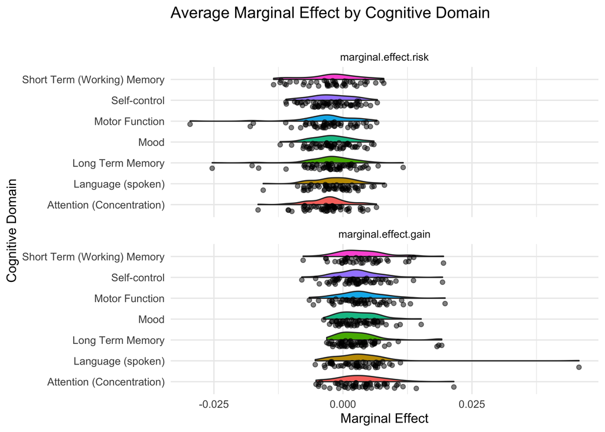

Descriptives for Risk by Cog domain

| type | condition | n | median | mean | sd | se | ci |
| --- | --- | --- | --- | --- | --- | --- | --- |
| marginal.effect.risk | Attention (Concentration) | 55 | -0.0028757 | -0.0030253 | 0.0041855 | 0.0005644 | 0.0011315 |
| marginal.effect.risk | Language (spoken) | 57 | -0.0016134 | -0.0017623 | 0.0041900 | 0.0005550 | 0.0011117 |
| marginal.effect.risk | Long Term Memory | 64 | -0.0023407 | -0.0024516 | 0.0055097 | 0.0006887 | 0.0013763 |
| marginal.effect.risk | Mood | 59 | -0.0022992 | -0.0022405 | 0.0037855 | 0.0004928 | 0.0009865 |
| marginal.effect.risk | Motor Function | 53 | -0.0030460 | -0.0032892 | 0.0061179 | 0.0008404 | 0.0016863 |
| marginal.effect.risk | Self-control | 59 | -0.0026917 | -0.0024096 | 0.0041576 | 0.0005413 | 0.0010835 |
| marginal.effect.risk | Short Term (Working) Memory | 45 | -0.0017116 | -0.0022805 | 0.0053432 | 0.0007965 | 0.0016053 |

Descriptives for Gain by Cog domain

| type | condition | n | median | mean | sd | se | ci |
| --- | --- | --- | --- | --- | --- | --- | --- |
| marginal.effect.gain | Attention (Concentration) | 55 | 0.0031578 | 0.0036320 | 0.0050056 | 0.0006750 | 0.0013532 |
| marginal.effect.gain | Language (spoken) | 57 | 0.0028027 | 0.0033836 | 0.0068350 | 0.0009053 | 0.0018136 |
| marginal.effect.gain | Long Term Memory | 64 | 0.0020691 | 0.0030185 | 0.0046061 | 0.0005758 | 0.0011506 |
| marginal.effect.gain | Mood | 59 | 0.0026927 | 0.0029580 | 0.0037309 | 0.0004857 | 0.0009723 |
| marginal.effect.gain | Motor Function | 53 | 0.0032174 | 0.0035275 | 0.0048633 | 0.0006680 | 0.0013405 |
| marginal.effect.gain | Self-control | 59 | 0.0026232 | 0.0027587 | 0.0045700 | 0.0005950 | 0.0011909 |
| marginal.effect.gain | Short Term (Working) Memory | 45 | 0.0034652 | 0.0037849 | 0.0051254 | 0.0007641 | 0.0015399 |

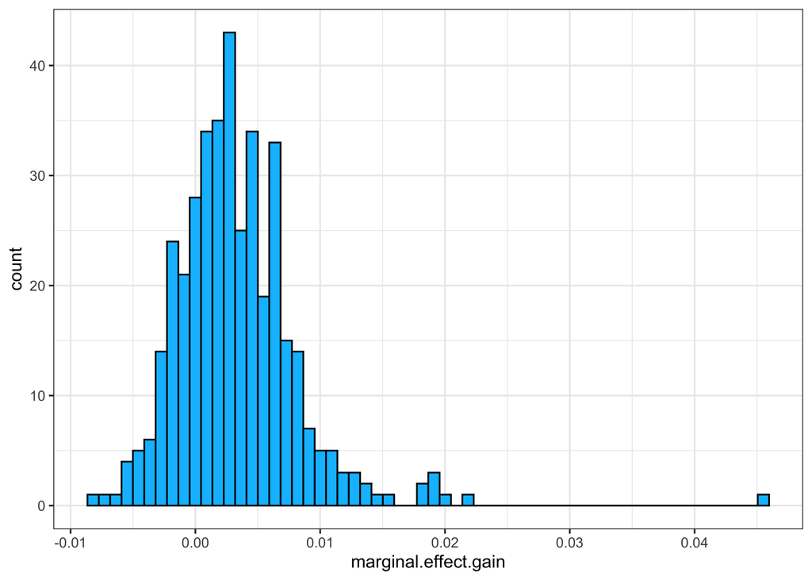

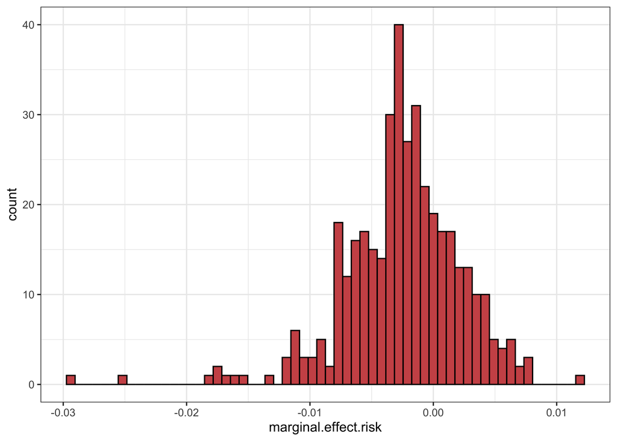

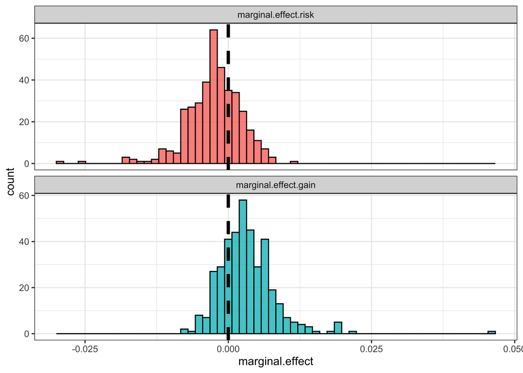

**##Statistical test for risk vs. benefit**

Parired T-test

| estimate | statistic | p.value | parameter | conf.low | conf.high | method |
| --- | --- | --- | --- | --- | --- | --- |
| -0.0057507 | -15.32264 | 0 | 391 | -0.0064885 | -0.0050128 | Paired t-test |

```
## t is large; approximation invoked.
```

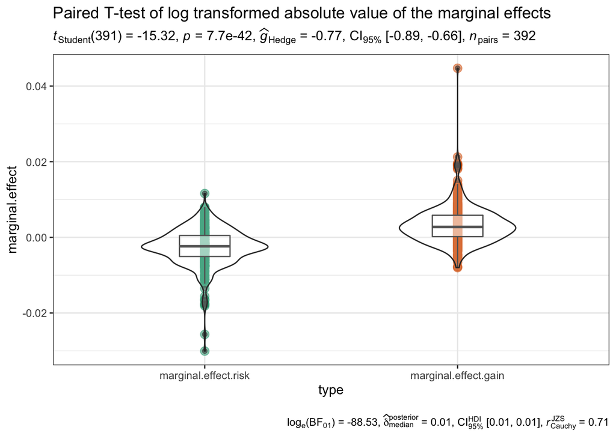

```
## # A tibble: 2 x 4
##   type                   median     mean      sd
##   <fct>                   <dbl>    <dbl>   <dbl>
## 1 marginal.effect.risk -0.00236 -0.00250 0.00481
## 2 marginal.effect.gain  0.00275  0.00325 0.00495
```

**##Interdomain stability**

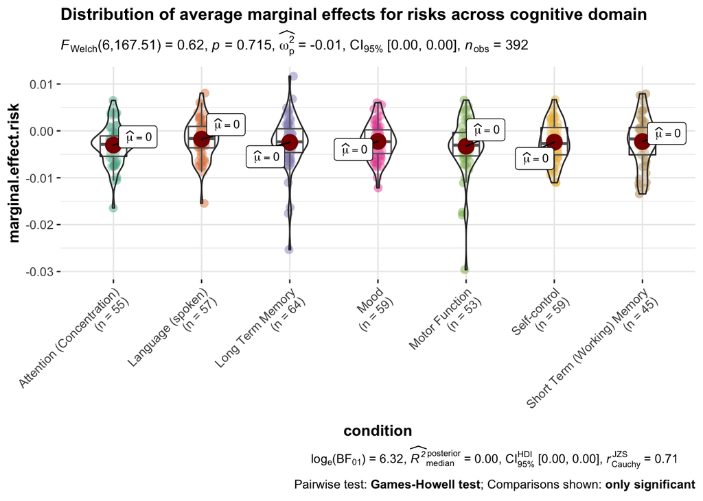

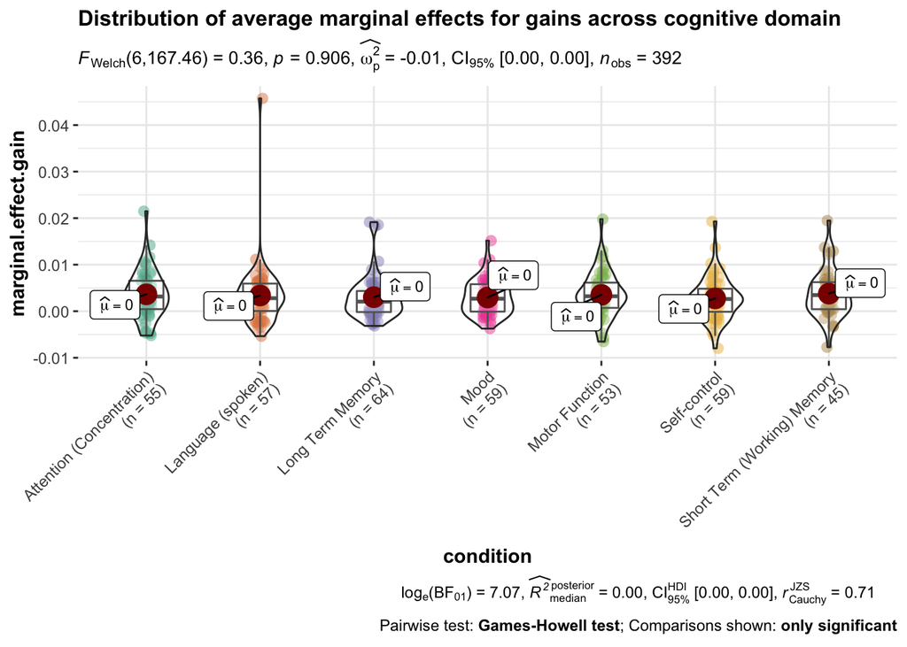

```
## Multiple parameters; naming those columns num.df, den.df
## Multiple parameters; naming those columns num.df, den.df
```

one way anova testing cognitve domain; (Risk and Gain)

| num.df | den.df | statistic | p.value | method |
| --- | --- | --- | --- | --- |
| 6 | 167.4974 | 0.6207750 | 0.7134863 | One-way analysis of means (not assuming equal variances) |
| 6 | 167.4703 | 0.3530244 | 0.9073747 | One-way analysis of means (not assuming equal variances) |

**##Do people use nonlinear weighting of probabilities?**

Model Comparison

| term | npar | AIC | BIC | logLik | deviance | statistic | df | p.value |
| --- | --- | --- | --- | --- | --- | --- | --- | --- |
| m.1 | 19 | 36185.04 | 36343.72 | -18073.52 | 36147.04 |  |  |  |
| m.2 | 20 | 36182.96 | 36350.00 | -18071.48 | 36142.96 | 4.076295 | 1 | 0.0434889 |
| m.3 | 21 | 36181.90 | 36357.29 | -18069.95 | 36139.90 | 3.063323 | 1 | 0.0800778 |
| m.4 | 22 | 36181.04 | 36364.78 | -18068.52 | 36137.04 | 2.858467 | 1 | 0.0908941 |
| m.5 | 23 | 36107.38 | 36299.48 | -18030.69 | 36061.38 | 75.656140 | 1 | 0.0000000 |
| m.6 | 24 | 36100.02 | 36300.47 | -18026.01 | 36052.02 | 9.360471 | 1 | 0.0022172 |
| m.7 | 25 | 36100.62 | 36309.42 | -18025.31 | 36050.62 | 1.403213 | 1 | 0.2361863 |

```
##
## # Predicted probabilities of experimental_treatment_selected
## # x = risk
##
## # gain = -1.29
##
##     x | Predicted |   SE |       95% CI
## ---------------------------------------
## -1.61 |      0.40 | 0.10 | [0.36, 0.45]
## -0.87 |      0.33 | 0.07 | [0.30, 0.36]
##  0.12 |      0.29 | 0.08 | [0.26, 0.32]
##  1.61 |      0.33 | 0.10 | [0.29, 0.37]
##
## # gain = -1.05
##
##     x | Predicted |   SE |       95% CI
## ---------------------------------------
## -1.61 |      0.43 | 0.08 | [0.39, 0.47]
## -0.87 |      0.36 | 0.07 | [0.33, 0.39]
##  0.12 |      0.30 | 0.07 | [0.27, 0.34]
##  1.61 |      0.31 | 0.09 | [0.28, 0.35]
##
## # gain = -0.8
##
##     x | Predicted |   SE |       95% CI
## ---------------------------------------
## -1.61 |      0.46 | 0.07 | [0.43, 0.50]
## -0.87 |      0.38 | 0.06 | [0.36, 0.41]
##  0.12 |      0.32 | 0.07 | [0.29, 0.35]
##  1.61 |      0.30 | 0.08 | [0.27, 0.33]
##
## # gain = -0.56
##
##     x | Predicted |   SE |       95% CI
## ---------------------------------------
## -1.61 |      0.49 | 0.07 | [0.46, 0.52]
## -0.87 |      0.41 | 0.06 | [0.38, 0.44]
##  0.12 |      0.34 | 0.07 | [0.31, 0.37]
##  1.61 |      0.29 | 0.08 | [0.26, 0.32]
##
```

[output cut: 114 more lines]

```
##  0.12 |      0.69 | 0.24 | [0.58, 0.78]
##  1.61 |      0.55 | 0.83 | [0.19, 0.86]
##
## # gain = 2.89
##
##     x | Predicted |   SE |       95% CI
## ---------------------------------------
## -1.61 |      0.54 | 0.11 | [0.49, 0.59]
## -0.87 |      0.66 | 0.11 | [0.61, 0.71]
##  0.12 |      0.72 | 0.29 | [0.59, 0.82]
##  1.61 |      0.60 | 0.94 | [0.19, 0.90]
##
## Adjusted for:
## * pearson.corr = -0.00
## *      user_id = 0 (population-level)
```

```
## Standard errors are on the link-scale (untransformed).
```

```
##
## # Predicted probabilities of experimental_treatment_selected
## # x = gain
##
## # risk = -1
##
##     x | Predicted |   SE |       95% CI
## ---------------------------------------
## -1.29 |      0.34 | 0.07 | [0.31, 0.37]
## -0.56 |      0.42 | 0.06 | [0.40, 0.45]
##  0.18 |      0.50 | 0.06 | [0.47, 0.53]
##  0.92 |      0.56 | 0.06 | [0.53, 0.59]
##  1.42 |      0.59 | 0.06 | [0.56, 0.62]
##  2.89 |      0.65 | 0.10 | [0.60, 0.69]
##
## # risk = 0
##
##     x | Predicted |   SE |       95% CI
## ---------------------------------------
## -1.29 |      0.29 | 0.08 | [0.26, 0.33]
## -0.56 |      0.35 | 0.07 | [0.32, 0.38]
##  0.18 |      0.42 | 0.07 | [0.38, 0.45]
##  0.92 |      0.49 | 0.07 | [0.46, 0.52]
##  1.42 |      0.55 | 0.08 | [0.51, 0.59]
##  2.89 |      0.72 | 0.25 | [0.61, 0.81]
##
## # risk = 1
##
##     x | Predicted |   SE |       95% CI
## ---------------------------------------
## -1.29 |      0.30 | 0.09 | [0.26, 0.33]
## -0.56 |      0.30 | 0.07 | [0.28, 0.33]
##  0.18 |      0.33 | 0.07 | [0.30, 0.37]
##  0.92 |      0.39 | 0.13 | [0.33, 0.45]
##  1.42 |      0.45 | 0.21 | [0.35, 0.55]
##  2.89 |      0.68 | 0.62 | [0.39, 0.88]
##
## Adjusted for:
## * pearson.corr = -0.00
## *      user_id = 0 (population-level)
```

```
## Standard errors are on the link-scale (untransformed).
```

```
## Random effect variances not available. Returned R2 does not account for random effects.
```

| Parameter | Coefficient | SE | CI_low | CI_high | z | p |
| --- | --- | --- | --- | --- | --- | --- |
| pearson.corr | -0.0537043 | 0.0519769 | -0.1555771 | 0.0481685 | -1.0332351 | 0.3014939 |
| risk | -0.3321582 | 0.0257000 | -0.3825292 | -0.2817872 | -12.9244669 | 0.0000000 |
| gain | 0.3988488 | 0.0282196 | 0.3435393 | 0.4541582 | 14.1337367 | 0.0000000 |
| I(risk^2) | 0.0115853 | 0.0245136 | -0.0364604 | 0.0596311 | 0.4726085 | 0.6364925 |
| I(gain^2) | 0.0228379 | 0.0312587 | -0.0384280 | 0.0841039 | 0.7306098 | 0.4650175 |
| risk:gain | -0.0848920 | 0.0364348 | -0.1563028 | -0.0134812 | -2.3299731 | 0.0198076 |
| risk:I(gain^2) | 0.0777286 | 0.0259196 | 0.0269271 | 0.1285301 | 2.9988328 | 0.0027102 |
| gain:I(risk^2) | -0.0906228 | 0.0295473 | -0.1485345 | -0.0327112 | -3.0670442 | 0.0021619 |

**Table 1:** main effects across all models with correlation included in model

|  | Model 1 |  |  |  | Model 2 |  |  |  | Model 3 |  |  |  | Model 4 |  |  |  | Model 5 |  |  |  | Model 6 |  |  |  |
| --- | --- | --- | --- | --- | --- | --- | --- | --- | --- | --- | --- | --- | --- | --- | --- | --- | --- | --- | --- | --- | --- | --- | --- | --- |
| Ind. Variable | Odds Ratios | CI | Statistic | p | Odds Ratios | CI | Statistic | p | Odds Ratios | CI | Statistic | p | Odds Ratios | CI | Statistic | p | Odds Ratios | CI | Statistic | p | Odds Ratios | CI | Statistic | p |
| (Intercept) | 0.7019 | 0.6297 – 0.7823 | -6.3937 | **<0.001** | 0.7220 | 0.6452 – 0.8079 | -5.6792 | **<0.001** | 0.6899 | 0.6101 – 0.7800 | -5.9236 | **<0.001** | 0.6984 | 0.6172 – 0.7903 | -5.6926 | **<0.001** | 0.6351 | 0.5594 – 0.7211 | -7.0088 | **<0.001** | 0.6607 | 0.5803 – 0.7522 | -6.2614 | **<0.001** |
| pearson.corr | 0.9518 | 0.8591 – 1.0546 | -0.9440 | 0.345 | 0.9503 | 0.8580 – 1.0525 | -0.9785 | 0.328 | 0.9500 | 0.8576 – 1.0524 | -0.9827 | 0.326 | 0.9536 | 0.8606 – 1.0567 | -0.9071 | 0.364 | 0.9494 | 0.8573 – 1.0514 | -0.9976 | 0.318 | 0.9477 | 0.8559 – 1.0493 | -1.0332 | 0.301 |
| risk | 0.8055 | 0.7727 – 0.8397 | -10.2015 | **<0.001** | 0.7969 | 0.7633 – 0.8319 | -10.3502 | **<0.001** | 0.7941 | 0.7607 – 0.8289 | -10.5237 | **<0.001** | 0.7815 | 0.7459 – 0.8187 | -10.3818 | **<0.001** | 0.7324 | 0.6976 – 0.7689 | -12.5457 | **<0.001** | 0.7174 | 0.6821 – 0.7544 | -12.9245 | **<0.001** |
| gain | 1.3247 | 1.2725 – 1.3791 | 13.7028 | **<0.001** | 1.3553 | 1.2936 – 1.4200 | 12.7845 | **<0.001** | 1.3627 | 1.3000 – 1.4285 | 12.8763 | **<0.001** | 1.3405 | 1.2745 – 1.4100 | 11.3662 | **<0.001** | 1.4604 | 1.3842 – 1.5408 | 13.8463 | **<0.001** | 1.4901 | 1.4099 – 1.5748 | 14.1337 | **<0.001** |
| gain^2 |  |  |  |  | 0.9727 | 0.9469 – 0.9992 | -2.0178 | **0.044** | 0.9677 | 0.9415 – 0.9947 | -2.3371 | **0.019** | 0.9503 | 0.9183 – 0.9834 | -2.9169 | **0.004** | 1.0903 | 1.0417 – 1.1412 | 3.7132 | **<0.001** | 1.0231 | 0.9623 – 1.0877 | 0.7306 | 0.465 |
| risk^2 |  |  |  |  |  |  |  |  | 1.0296 | 0.9975 – 1.0627 | 1.8072 | 0.071 | 1.0148 | 0.9792 – 1.0516 | 0.8047 | 0.421 | 1.0606 | 1.0219 – 1.1008 | 3.1019 | **0.002** | 1.0117 | 0.9642 – 1.0614 | 0.4726 | 0.636 |
| risk * gain |  |  |  |  |  |  |  |  |  |  |  |  | 0.9584 | 0.9138 – 1.0051 | -1.7494 | 0.080 | 0.9968 | 0.9497 – 1.0463 | -0.1298 | 0.897 | 0.9186 | 0.8553 – 0.9866 | -2.3300 | **0.020** |
| risk * gain^2 |  |  |  |  |  |  |  |  |  |  |  |  |  |  |  |  | 1.1512 | 1.1161 – 1.1873 | 8.9192 | **<0.001** | 1.0808 | 1.0273 – 1.1372 | 2.9988 | **0.003** |
| gain * risk^2 |  |  |  |  |  |  |  |  |  |  |  |  |  |  |  |  |  |  |  |  | 0.9134 | 0.8620 – 0.9678 | -3.0670 | **0.002** |
| Random Effects |  |  |  |  |  |  |  |  |  |  |  |  |  |  |  |  |  |  |  |  |  |  |  |  |
| σ<sup>2</sup> | 3.29 |  |  |  | 3.29 |  |  |  | 3.29 |  |  |  | 3.29 |  |  |  | 3.29 |  |  |  | 3.29 |  |  |  |
| τ<sub>00</sub> | 1.46 <sub>user_id</sub> |  |  |  | 1.47 <sub>user_id</sub> |  |  |  | 1.47 <sub>user_id</sub> |  |  |  | 1.47 <sub>user_id</sub> |  |  |  | 1.51 <sub>user_id</sub> |  |  |  | 1.52 <sub>user_id</sub> |  |  |  |
| τ<sub>11</sub> | 0.10 <sub>user_id.risk</sub> |  |  |  | 0.10 <sub>user_id.risk</sub> |  |  |  | 0.10 <sub>user_id.risk</sub> |  |  |  | 0.10 <sub>user_id.risk</sub> |  |  |  | 0.10 <sub>user_id.risk</sub> |  |  |  | 0.10 <sub>user_id.risk</sub> |  |  |  |
|  | 0.11 <sub>user_id.gain</sub> |  |  |  | 0.11 <sub>user_id.gain</sub> |  |  |  | 0.12 <sub>user_id.gain</sub> |  |  |  | 0.12 <sub>user_id.gain</sub> |  |  |  | 0.11 <sub>user_id.gain</sub> |  |  |  | 0.11 <sub>user_id.gain</sub> |  |  |  |
|  | 0.02 <sub>user_id.I(gain^2)</sub> |  |  |  | 0.02 <sub>user_id.I(gain^2)</sub> |  |  |  | 0.02 <sub>user_id.I(gain^2)</sub> |  |  |  | 0.02 <sub>user_id.I(gain^2)</sub> |  |  |  | 0.02 <sub>user_id.I(gain^2)</sub> |  |  |  | 0.02 <sub>user_id.I(gain^2)</sub> |  |  |  |
|  | 0.01 <sub>user_id.I(risk^2)</sub> |  |  |  | 0.01 <sub>user_id.I(risk^2)</sub> |  |  |  | 0.01 <sub>user_id.I(risk^2)</sub> |  |  |  | 0.01 <sub>user_id.I(risk^2)</sub> |  |  |  | 0.01 <sub>user_id.I(risk^2)</sub> |  |  |  | 0.01 <sub>user_id.I(risk^2)</sub> |  |  |  |
| ρ<sub>01</sub> | 0.37 |  |  |  | 0.37 |  |  |  | 0.36 |  |  |  | 0.36 |  |  |  | 0.36 |  |  |  | 0.37 |  |  |  |
|  | -0.16 |  |  |  | -0.16 |  |  |  | -0.17 |  |  |  | -0.16 |  |  |  | -0.14 |  |  |  | -0.14 |  |  |  |
|  | -0.07 |  |  |  | -0.09 |  |  |  | -0.08 |  |  |  | -0.09 |  |  |  | -0.16 |  |  |  | -0.14 |  |  |  |
|  | -0.84 |  |  |  | -0.84 |  |  |  | -0.84 |  |  |  | -0.83 |  |  |  | -0.84 |  |  |  | -0.87 |  |  |  |
| N | 425 <sub>user_id</sub> |  |  |  | 425 <sub>user_id</sub> |  |  |  | 425 <sub>user_id</sub> |  |  |  | 425 <sub>user_id</sub> |  |  |  | 425 <sub>user_id</sub> |  |  |  | 425 <sub>user_id</sub> |  |  |  |
| Observations | 31318 |  |  |  | 31318 |  |  |  | 31318 |  |  |  | 31318 |  |  |  | 31318 |  |  |  | 31318 |  |  |  |
| Marginal R<sup>2</sup> / Conditional R<sup>2</sup> | 0.055 / NA |  |  |  | 0.057 / NA |  |  |  | 0.059 / NA |  |  |  | 0.058 / NA |  |  |  | 0.061 / NA |  |  |  | 0.062 / NA |  |  |  |

*Note:* Standardized parameters were obtained by fitting the model on a standardized version of the dataset. 95% Confidence Intervals (CIs) and p-values were computed using the Wald approximation.

#Individual Differences

Note I have run these without the outliers and with; no difference. ##**Age**

[figure not shown]

| **Characteristic** | **Beta** | **95% CI**<sup>1</sup> | **p-value** |
| --- | --- | --- | --- |
| age | -0.04 | -0.10, 0.02 | 0.2 |

<sup>*1*</sup> CI = Confidence Interval

| **Characteristic** | **Beta** | **95% CI**<sup>1</sup> | **p-value** |
| --- | --- | --- | --- |
| age | 0.01 | -0.05, 0.07 | 0.7 |

<sup>*1*</sup> CI = Confidence Interval

**We did not find any individual differenece in risk or gain as a function of age**

##**Education**

Descriptives for risk by education

| education | n | mean | sd | se | ci |
| --- | --- | --- | --- | --- | --- |
| HighSchool | 108 | -0.0032693 | 0.0045185 | 0.0004348 | 0.0008619 |
| Undergraduate | 224 | -0.0024627 | 0.0049861 | 0.0003332 | 0.0006565 |
| Postgraduate | 59 | -0.0009921 | 0.0039381 | 0.0005127 | 0.0010263 |

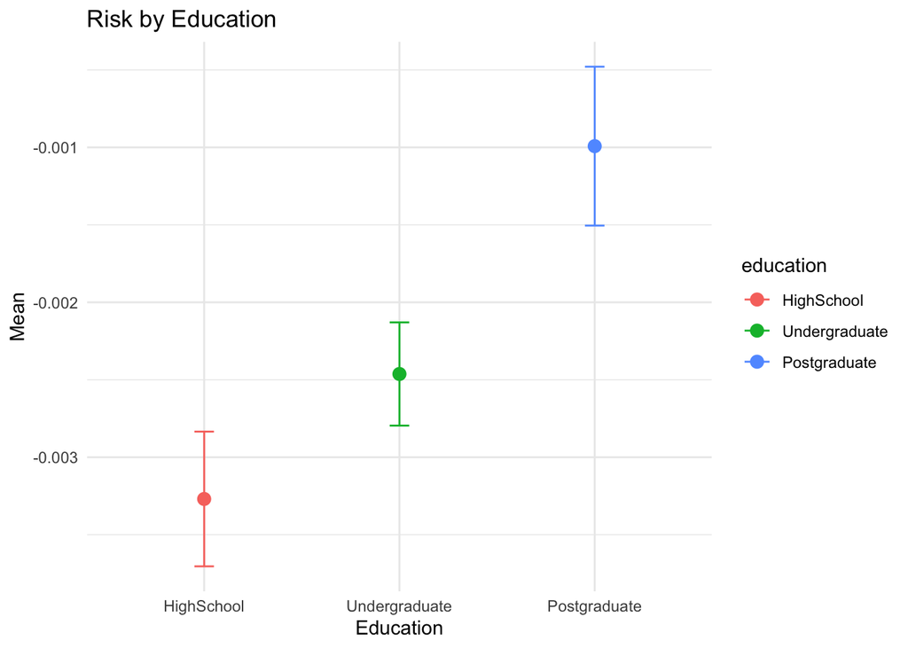

Descriptives for gain by education

| education | n | mean | sd | se | ci |
| --- | --- | --- | --- | --- | --- |
| HighSchool | 108 | 0.0038975 | 0.0035066 | 0.0003374 | 0.0006689 |
| Undergraduate | 224 | 0.0033325 | 0.0055162 | 0.0003686 | 0.0007263 |
| Postgraduate | 59 | 0.0016060 | 0.0045900 | 0.0005976 | 0.0011962 |

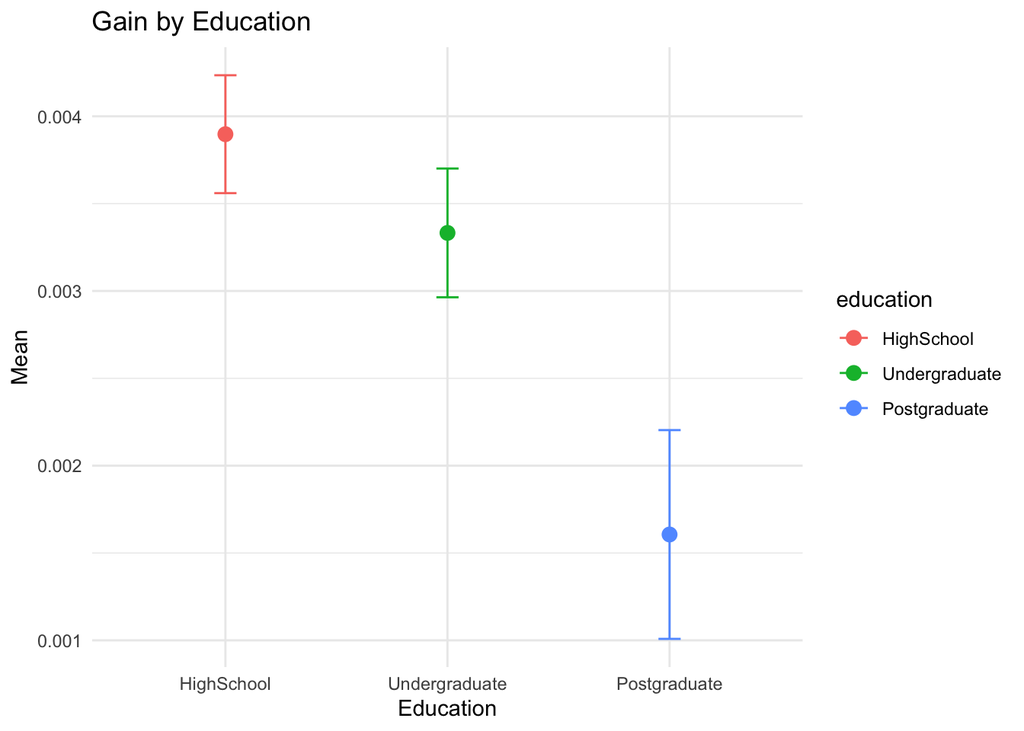

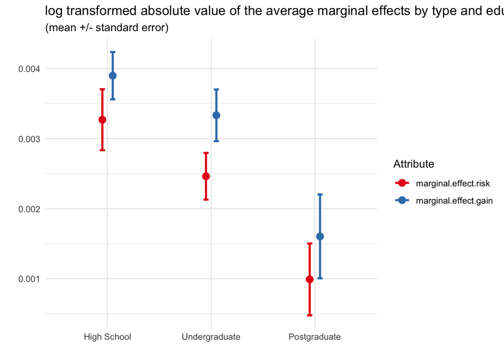

Predicting Risk given Categorical Education

| term | estimate | std.error | statistic | p.value |
| --- | --- | --- | --- | --- |
| (Intercept) | -0.0032693 | 0.0004538 | -7.204841 | 0.0000000 |
| educationUndergraduate | 0.0008066 | 0.0005524 | 1.460147 | 0.1450588 |
| educationPostgraduate | 0.0022772 | 0.0007634 | 2.982873 | 0.0030359 |

pairwise comparaisions of average marginal effects for risk by education

| contrast | estimate | std.error | df | statistic | adj.p.value |
| --- | --- | --- | --- | --- | --- |
| HighSchool - Undergraduate | -0.0008066 | 0.0005524 | 388 | -1.460147 | 0.3113663 |
| HighSchool - Postgraduate | -0.0022772 | 0.0007634 | 388 | -2.982873 | 0.0085127 |
| Undergraduate - Postgraduate | -0.0014706 | 0.0006901 | 388 | -2.131060 | 0.0849571 |

Predicting Gain given Categorical Education

| term | estimate | std.error | statistic | p.value |
| --- | --- | --- | --- | --- |
| (Intercept) | 0.0038975 | 0.0004717 | 8.2629037 | 0.0000000 |
| educationUndergraduate | -0.0005650 | 0.0005742 | -0.9838765 | 0.3257894 |
| educationPostgraduate | -0.0022916 | 0.0007936 | -2.8876434 | 0.0040987 |

pairwise comparaisions of average marginal effects for gain by education

| contrast | estimate | std.error | df | statistic | adj.p.value |
| --- | --- | --- | --- | --- | --- |
| HighSchool - Undergraduate | 0.0005650 | 0.0005742 | 388 | 0.9838765 | 0.5874979 |
| HighSchool - Postgraduate | 0.0022916 | 0.0007936 | 388 | 2.8876434 | 0.0114002 |
| Undergraduate - Postgraduate | 0.0017266 | 0.0007173 | 388 | 2.4069861 | 0.0435907 |

Predicting AME given R/B and education

| term | estimate | std.error | statistic | p.value |
| --- | --- | --- | --- | --- |
| (Intercept) | -0.0032693 | 0.0004628 | -7.064014 | 0.0000000 |
| typemarginal.effect.gain | 0.0071668 | 0.0006545 | 10.949781 | 0.0000000 |
| educationUndergraduate | 0.0008066 | 0.0005634 | 1.431607 | 0.1526589 |
| educationPostgraduate | 0.0022772 | 0.0007786 | 2.924570 | 0.0035498 |
| typemarginal.effect.gain:educationUndergraduate | -0.0013716 | 0.0007968 | -1.721342 | 0.0855873 |
| typemarginal.effect.gain:educationPostgraduate | -0.0045687 | 0.0011012 | -4.149001 | 0.0000371 |

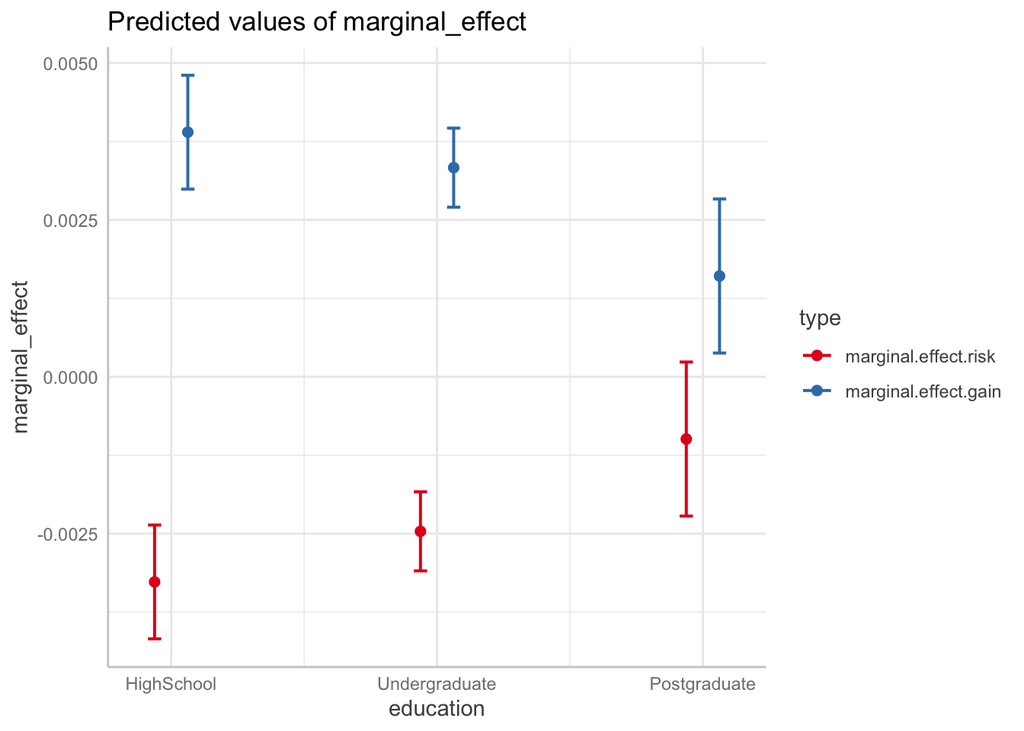

WE found a significant difference between high school and postgrad

##**Income**

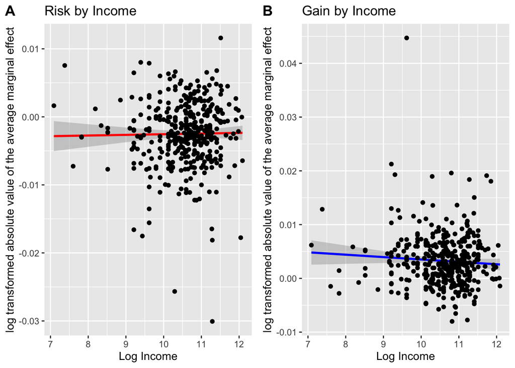

| **Characteristic** | **Beta** | **95% CI**<sup>1</sup> | **p-value** |
| --- | --- | --- | --- |
| Income | 0.00 | 0.00, 0.00 | 0.8 |

<sup>*1*</sup> CI = Confidence Interval

| **Characteristic** | **Beta** | **95% CI**<sup>1</sup> | **p-value** |
| --- | --- | --- | --- |
| Income | 0.00 | 0.00, 0.00 | 0.2 |

<sup>*1*</sup> CI = Confidence Interval

**We did not find any individual differenece in risk or gain as a function of log Income**

##**Sex**

Descriptives for risk by sex

| sex | n | mean | sd | se | ci |
| --- | --- | --- | --- | --- | --- |
| Male | 226 | -0.0027171 | 0.0049389 | 0.0003285 | 0.0006474 |
| Female | 161 | -0.0022002 | 0.0046366 | 0.0003654 | 0.0007217 |

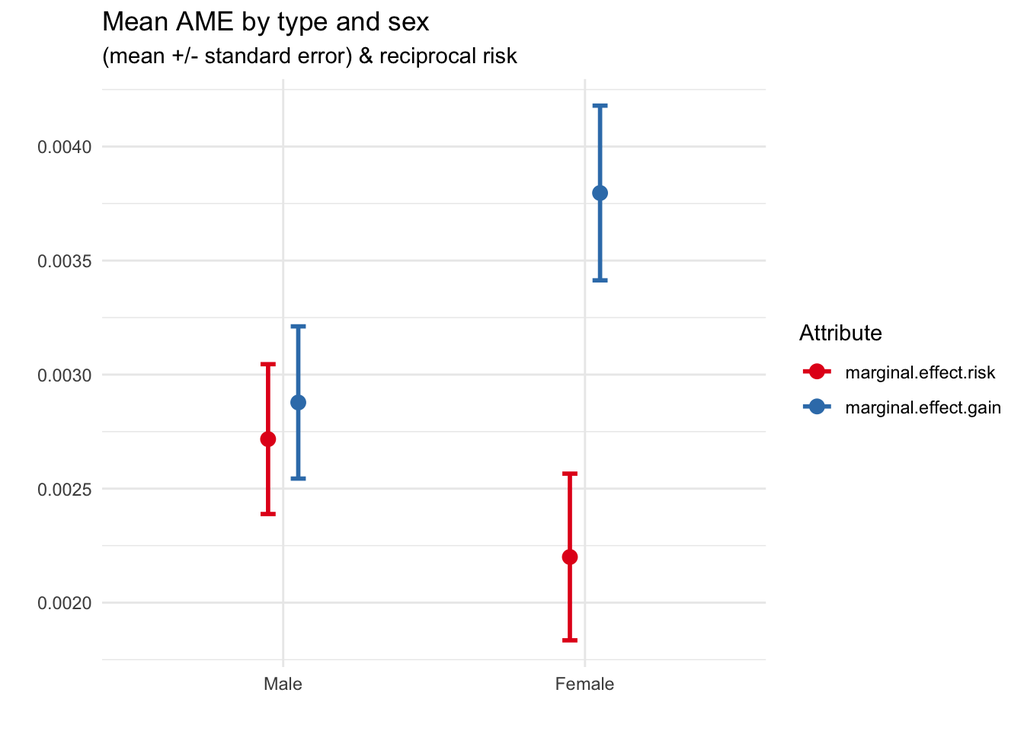

Predicting Risk given Categorical sex

| term | estimate | std.error | statistic | p.value |
| --- | --- | --- | --- | --- |
| (Intercept) | -0.0027171 | 0.0003203 | -8.482395 | 0.0000000 |
| sexFemale | 0.0005169 | 0.0004966 | 1.040809 | 0.2986175 |

Predicting Gain given Categorical sex

| term | estimate | std.error | statistic | p.value |
| --- | --- | --- | --- | --- |
| (Intercept) | 0.0028777 | 0.0003295 | 8.734659 | 0.0000000 |
| sexFemale | 0.0009186 | 0.0005108 | 1.798339 | 0.0729066 |

Predicting AME given R/B and sex

| term | estimate | std.error | statistic | p.value |
| --- | --- | --- | --- | --- |
| (Intercept) | -0.0027171 | 0.0003249 | -8.3622928 | 0.0000000 |
| typemarginal.effect.gain | 0.0055949 | 0.0004595 | 12.1756002 | 0.0000000 |
| sexFemale | 0.0005169 | 0.0005038 | 1.0260720 | 0.3051799 |
| typemarginal.effect.gain:sexFemale | 0.0004017 | 0.0007124 | 0.5638284 | 0.5730351 |

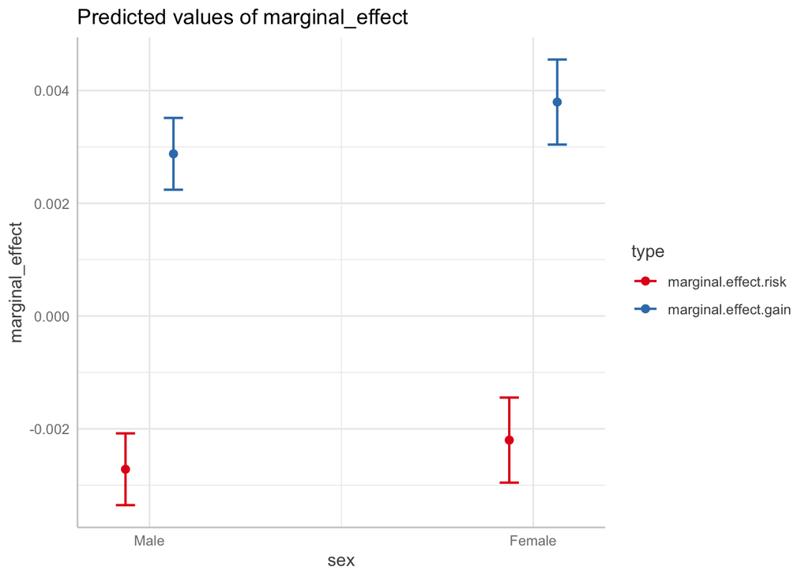

##**Race**

Descriptives for risk by race

| race_ethnicity | n | mean | sd | se | ci |
| --- | --- | --- | --- | --- | --- |
| Non-White | 121 | -0.0022211 | 0.0048648 | 0.0004423 | 0.0008756 |
| White | 268 | -0.0026044 | 0.0048063 | 0.0002936 | 0.0005780 |

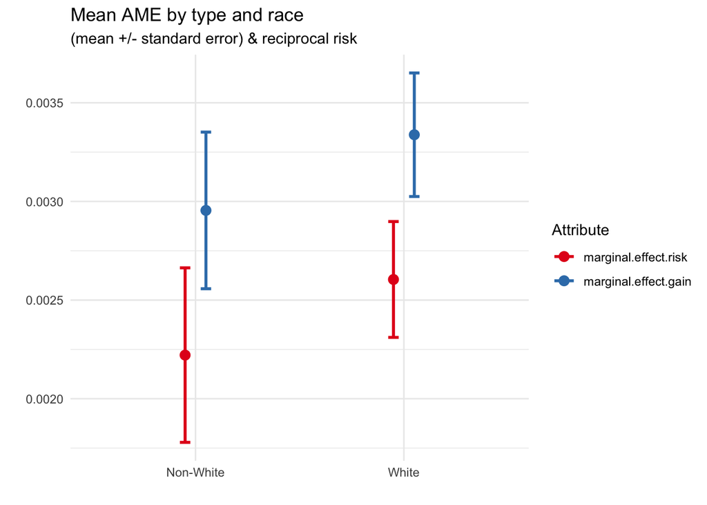

Predicting Risk given Categorical race_ethnicity

| term | estimate | std.error | statistic | p.value |
| --- | --- | --- | --- | --- |
| (Intercept) | -0.0022211 | 0.0004386 | -5.0642159 | 0.0000006 |
| race_ethnicityWhite | -0.0003833 | 0.0005284 | -0.7254094 | 0.4686393 |

Predicting Gain given Categorical race_ethnicity

| term | estimate | std.error | statistic | p.value |
| --- | --- | --- | --- | --- |
| (Intercept) | 0.0029545 | 0.0004457 | 6.6286140 | 0.0000000 |
| race_ethnicityWhite | 0.0003835 | 0.0005370 | 0.7142036 | 0.4755318 |

Predicting AME given R/B and race_ethnicity

| term | estimate | std.error | statistic | p.value |
| --- | --- | --- | --- | --- |
| (Intercept) | -0.0021360 | 0.0004508 | -4.7377543 | 0.0000026 |
| YN_diff | 0.0000067 | 0.0000069 | 0.9684343 | 0.3331304 |
| typemarginal.effect.gain | 0.0051756 | 0.0006253 | 8.2763921 | 0.0000000 |
| race_ethnicityWhite | -0.0003699 | 0.0005329 | -0.6941323 | 0.4878078 |
| typemarginal.effect.gain:race_ethnicityWhite | 0.0007668 | 0.0007534 | 1.0178224 | 0.3090808 |

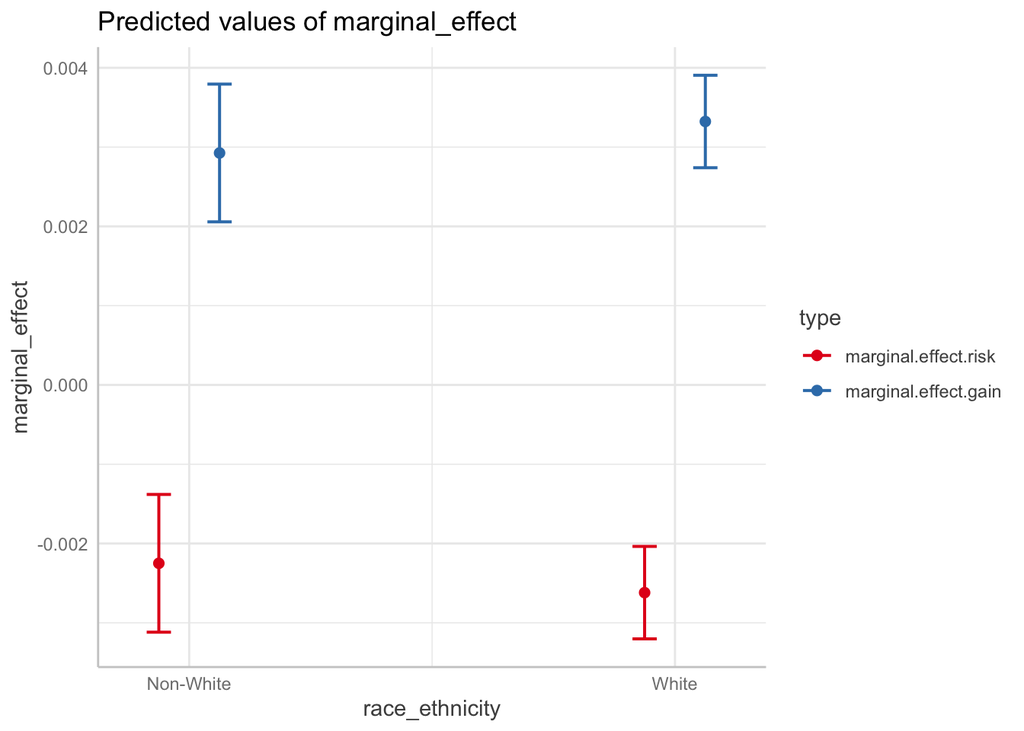

#mulitple regression

#suppTable S3

For each state the model formula, results and fixed effect terms:

```
## [[1]]
## glmer(formula = experimental_treatment_selected ~ pearson.corr +
##     risk + gain + (risk + gain + I(gain^2) + I(risk^2) | user_id),
##     data = test, family = binomial(link = "logit"), control = glmerControl(optimizer = "bobyqa"),
##     nAGQ = 0)
##
## [[2]]
## # A tibble: 1 x 5
##      AIC    BIC  logLik deviance df.residual
##    <dbl>  <dbl>   <dbl>    <dbl>       <int>
## 1 36185. 36344. -18074.   33403.       31299
##
## [[3]]
## # A tibble: 4 x 5
##   term         estimate std.error statistic  p.value
##   <chr>           <dbl>     <dbl>     <dbl>    <dbl>
## 1 (Intercept)   -0.354     0.0554    -6.39  1.62e-10
## 2 pearson.corr  -0.0494    0.0523    -0.944 3.45e- 1
## 3 risk          -0.216     0.0212   -10.2   1.95e-24
## 4 gain           0.281     0.0205    13.7   9.77e-43
##
## [[1]]
## glmer(formula = experimental_treatment_selected ~ pearson.corr +
##     risk + gain + I(gain^2) + (risk + gain + I(gain^2) + I(risk^2) |
##     user_id), data = test, family = binomial(link = "logit"),
##     control = glmerControl(optimizer = "bobyqa"), nAGQ = 0)
##
## [[2]]
## # A tibble: 1 x 5
##      AIC    BIC  logLik deviance df.residual
##    <dbl>  <dbl>   <dbl>    <dbl>       <int>
## 1 36183. 36350. -18071.   33416.       31298
##
## [[3]]
## # A tibble: 5 x 5
##   term         estimate std.error statistic  p.value
##   <chr>           <dbl>     <dbl>     <dbl>    <dbl>
## 1 (Intercept)   -0.326     0.0574    -5.68  1.35e- 8
## 2 pearson.corr  -0.0510    0.0521    -0.978 3.28e- 1
## 3 risk          -0.227     0.0219   -10.4   4.18e-25
```

[output cut: 115 more lines]

```
##
## [[3]]
## # A tibble: 10 x 5
##    term                estimate std.error statistic  p.value
##    <chr>                  <dbl>     <dbl>     <dbl>    <dbl>
##  1 (Intercept)         -0.406      0.0665    -6.10  1.05e- 9
##  2 pearson.corr        -0.0532     0.0520    -1.02  3.06e- 1
##  3 risk                -0.335      0.0258   -13.0   1.55e-38
##  4 gain                 0.413      0.0303    13.6   2.51e-42
##  5 I(risk^2)            0.00396    0.0252     0.157 8.75e- 1
##  6 I(gain^2)            0.0178     0.0315     0.563 5.73e- 1
##  7 risk:gain           -0.0606     0.0411    -1.47  1.41e- 1
##  8 risk:I(gain^2)       0.104      0.0329     3.15  1.66e- 3
##  9 gain:I(risk^2)      -0.0836     0.0301    -2.78  5.43e- 3
## 10 I(risk^2):I(gain^2)  0.0225     0.0177     1.27  2.04e- 1
```